# Personal Vehicle Depreciation: Electric vs. Combustion

##### ID: 915219297

##### 12/11/2023

# Introduction

Innovation in the automotive industry is required to drive us to a sustainable future. Electric vehicles are the next step for the industry to adopt. Removing internal combustion engine vehicles (ICEV) from the road will help fight climate change, give us cleaner air in metropolitan areas, and reduce our dependence on fossil fuels.

In recent years, fully electric vehicles (EVs) still only make up about 1% Blanco (2022) of all cars on the road in the United States. However, data from recent car sales show that about 8% of vehicles bought during Q3 of 203 were electric Automotive (2023). Trends are looking optimistic, and it will only be a matter of time before EVs become the vehicles of choice for all Americans.

Owning an EV is different from a traditional gas-powered car in multiple ways. A costly and heavy battery pack replaces the gas tank, and a simpler electric motor replaces the complex combustion engine. However, the heavy battery on the bottom of the vehicle drastically improves stability, making the car safer. No oil changes are necessary. Besides the occasional brake inspection and tire change, EVs have little operating cost compared to their gas-powered counterparts. EV owners worry about getting to their destination, which makes their ‘range’ a vital specification when comparing EVs. Then there is the unknown about the battery’s life expectancy and cost of replacement. As technology quickly evolves in the battery sector, one might fear that their three-year-old EV will be obsolete soon.

This paper will open with a literature review on depreciation and other factors influencing EV price economics. Following that, the paper will highlight the data used and the methodologies used to answer the research questions. The results and a discussion follow these sections. The paper will finish with a conclusion, including the limitations of this paper.

# Literature Review

Addressing the issue of depreciation or value loss for EVs is essential to be adopted by the general population. There are several reasons why consumers think it is a bad investment to opt for an EV. Consumers often view EVs and consumer electronic batteries as similar. Excellent care will still send the best batteries to the recycling bin within three to five years. Nevertheless, EV batteries are different and can last much longer.

Zang, Wang, and Qi (2022) research highlights some interesting facts about the EV battery. They introduce the idea that measuring an EV’s deprecation by time or millage without considering the battery’s condition is unwise. Given that the battery makes up about 40% of the cost of building an EV König et al. (2021), one should include when determining the amount an EV depreciates. Zang, Wang, and Qi (2022) identifies the depth-of-discharge (DOD) to significantly impact the deprecation of the battery, which they mention leads to a naturally nonlinear depreciation function. DOD refers to the amount a battery uses (discharges) from the previous charge till it is plugged in again, unlike conventional car depreciation functions, which see age and mileage as linear factors. This paper will not be able to use the battery’s condition as a variable. However, this insight makes a case for adding quadratic terms to find nonlinear trends in the data.

Government intervention plays a role in consumers’ consideration of buying an EV. Incentives such as subsidies, tax breaks, and access to High-Occupancy Vehicle (HOV) lanes are all meant to entice consumers to switch to electric driving. In addition to the cost-benefit of lower operating costs, it is a no-brainer. However, Rapson and Muehlegger (2023) lists many reasons to think again before committing to the future. In their paper, Rapson and Muehlegger (2023) mention the lower range and longer refill times compared to ICEs. Electricity and gas prices vary widely in the U.S., making charging more expensive than fueling in certain areas. The only actual maintenance cost of EVs comes years after purchase when the car needs a new battery, which could cost up to $10,000. Compared to the average cost of $200 annually for ICE vehicles. The paper mentions that this information is complex to compare due to the need for historical data on EVs and the potential to reduce the cost of batteries.

The government intends to reduce carbon emissions by offering financial incentives to new EV drivers, but Rapson and Muehlegger (2023) states that the electricity created for EVs is far from clean. Rather than having carbon dioxide burn right where ICE vehicles drive, EVs send their greenhouse gas emissions to another place in the country. Depending on the lifecycle of an EV, they can sometimes pollute more than traditional cars. The nationwide electricity grid is also transitioning to green energy and will make EVs much cleaner as this progresses.

In their research, Breetz and Salon (2018) discusses the necessity for EV subsidies. As previously mentioned, many factors, including location, will determine if an EV will be worth the premium price tag. Breetz and Salon (2018) concluded that EV costs substantially more throughout five-year ownership in 13 out of 14 cities they analyzed. The biggest driver of this cost discrepancy is depreciation. The EVs lost more value in 5 years than they saved in gas and other expenses. This study analyzed vehicles between 2011 and 2015 with a 24 and 30 kWh capacity Nissan Leaf, which gives about a 100-mile range. For comparison, the base Tesla Model 3 had 54 kWh back in 2019.

This paper is similar in research objective and approach in contrast to Schloter (2022). Both aim to find the comparative depreciation between EVs and ICEVs. However, MSRP was unavailable in this paper’s data, making it more about the vehicle’s expected value than direct depreciation. Schloter (2022) finds that EVs depreciate substantially faster than ICEVs. The data they used is from various countries and mainly aims to demonstrate the depreciation rate over time. This paper takes a similar approach to find the vehicle’s value as they age and travel further.

# Data Overview

The vehicle sales data used for this research was captured from eBay over 20 months between 2018 and 2020. The raw data consists of over 120 thousand sales records in the U.S. and Canada. The data provider, a Kaggle user ‘tsaustin,’ documented Python code that verifies that no duplicates are present. Since EVs were not a significant part of the mass passenger vehicle market, vehicles built years prior to 2003 have no use in the data. Outliers with extremely high or low sales prices, milages recorded over 150 thousand, and vehicles with insufficient information are dropped from the data. To avoid including collectible vehicles, brands with 50 or fewer records in the remaining data set are also removed.

#### Table 1

Head of Original Data (source: https://www.kaggle.com/datasets/tsaustin/us-used-car-sales-data/)

| ID | pricesold | yearsold | zipcode | Mileage | Make | Model | Year | Trim | Engine | BodyType | NumCylinders | DriveType |
| --- | --- | --- | --- | --- | --- | --- | --- | --- | --- | --- | --- | --- |
| 137178 | 7500 | 2020 | 786** | 84430 | Ford | Mustang | 1988 | LX | 5.0L Gas V8 | Sedan | 0 | RWD |
| 96705 | 15000 | 2019 | 81006 | 0 | Replica/Kit Makes | Jaguar Beck Lister | 1958 |  | 383 Fuel injected | Convertible | 8 | RWD |
| 119660 | 8750 | 2020 | 33449 | 55000 | Jaguar | XJS | 1995 | 2+2 Cabriolet | 4.0L In-Line 6 Cylinder | Convertible | 6 | RWD |
| 80773 | 11600 | 2019 | 07852 | 97200 | Ford | Mustang | 1968 | Stock | 289 cu. in. V8 | Coupe | 8 | RWD |
| 64287 | 44000 | 2019 | 07728 | 40703 | Porsche | 911 | 2002 | Turbo X-50 | 3.6L | Coupe | 6 | AWD |
| 132695 | 950 | 2020 | 462** | 71300 | Mercury | Montclair | 1965 |  | NO ENGINE | Sedan | 0 | RWD |

The raw data set includes 13 variables that help identify each vehicle’s ‘Power By’ designation: Electric, Hybrid, and Gas. Gas vehicles refer to both ICEVs powered by gas and diesel. Once identified, the Hybrid vehicles are dropped from the data as this research focuses on the difference between ICEVs and EVs. After filtering out unuseful data, the number of sales records available for regression is 36,229 for ICEVs and EVs combined.

#### Table 2

Summary of Observations

| PowerBy | # of Vehicles |
| --- | --- |
| Gas | 35638 |
| Unknown | 3513 |
| Electric | 591 |
| Hybrid | 491 |

#### Figure 1

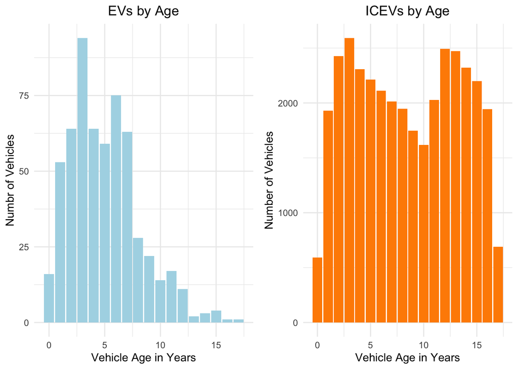

#### Figure 2

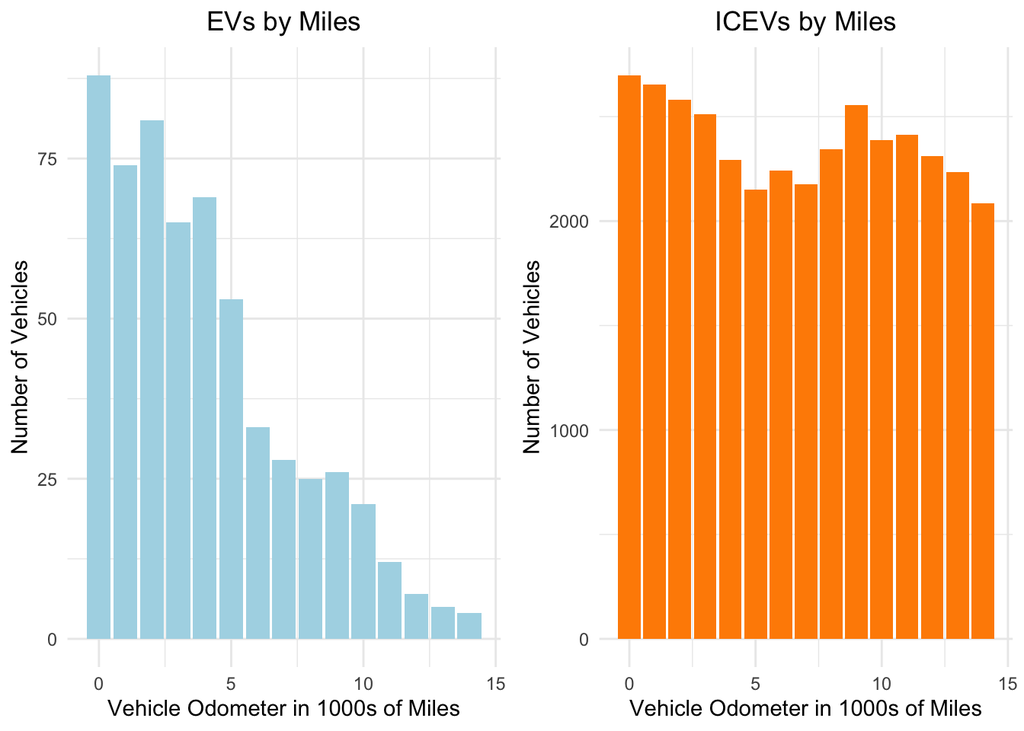

# Methodology

The regression for this analysis consists of variables to ensure the highest possible accuracy for the results that will answer the research questions. The dependent variable for this research is the log function of ‘price sold.’ Prior research showed a strong correlation between mileage and car age. This notion holds in this data set. The regression needs a ratio interaction between the two to avoid any errors resulting from multicollinearity. Additionally, during the COVID-19 crisis, new and second-hand vehicles increased in price due to supply chain issues. The regression includes the year a vehicle was sold as a factor variable to account for this price shift.

The regression includes dummy variables indicating the vehicle’s origin, domestic, Asia, or Europe, where ‘domestic’ is the omitted variable. The vehicles’ origins are identified by their ‘Make.’ During the experimentation phase of this research, many ‘Makes’ did not provide significant results. Collecting them into broader categories improved the output of the regressions.

‘Mileage’ and ‘Car Age’ are also regressed as factors to understand better when depreciation happens. The omitted factor for Mileage is vehicles driven between 0 and 25K miles. The subsequent factors are miles 25K to 50K and miles over 50K. During the experimentation, another factor was added but showed no improvements to the significance of the results. Car Age is similar, with the lowest age of 0 to 3 years omitted. The subsequent factors are 4 to 6 years, 7 to 10 years, and over ten years.

#### Regression

$$ln(P_{i})= \beta_{0} + \beta_{1} \cdot {\frac {M_{i}} {A_{i}}} +
\beta_{2} \cdot
Y_{i} + \delta_{1} \cdot O_{asia} + \delta_{2} \cdot O_{euro} +
\delta_{3} \cdot M_{25-50}
+ \delta_{4} \cdot M_{50+} + \delta_{5} \cdot A_{4-6} + \delta_{6} \cdot
A_{7-10}
+ \delta_{7} \cdot A_{10+}$$

$P_{i}$: price of vehicle sold

$M_{i}$: 1000s miles driven

$A_{i}$: vehicle age in years

$Y_{i}$: year the vehicle was sold (factor)

$O_{asia}$: vehicle origin is Asia (dummy)

$O_{euro}$: vehicle origin is Europe (dummy)

$M_{25-50}$: vehicle odometer between 25K & 50K miles (dummy)

$M_{50+}$: vehicle odometer over 50K miles (dummy)

$A_{4-6}$: vehicle age between 4 & 6 years (dummy)

$A_{7-10}$: vehicle age between 7 & 10 years (dummy)

$A_{4-6}$: vehicle age over 10 years (dummy)

The same regression is run on EVs and ICEVs separately. This way, a side-by-side comparison can clearly identify differences in the results. All the previously described variables are added to our linear model and quantile regression to see which section of the data is mainly affected by age and mileage.

# Results

The results of the linear model regressions show that most variables provided significant results. The $R^2$ for the model on the EV data set is 0.746, whereas the ICEVs model’s $R^2$ is 0.439. The ‘Mileage’ over ‘Car Age’ interaction provides little conclusive information other than a correlation between the two. ‘Year Sold’ provides little significant data other than the expected increase in price in 2020 for ICEVs. The EVs give insignificant results, likely due to the small number of observations relative to those of ICEVs.

The ‘origin’ factor gives a surprising result for European vehicles. European EVs have a lower price sold than domestic, whereas for ICEVs, it is the opposite. One explanation can be that domestic EVs, such as Tesla, are relatively more pricey than domestic ICEVs. Additionally, Many EVs shipped from overseas tend to be designed for city driving and are smaller.

To answer Q1, we look at the result of the ‘Car Age’ factors provided at the bottom. At a glance, it is easy to confirm the consensus that EVs depreciate quicker as the car ages compared to ICEVs. Only after 10+ years of age have both types of vehicles lost enough value to where they become close in depreciation.

#### Linear Model Results

```
##
## ===========================================================================
##                                       Dependent variable:
##                     -------------------------------------------------------
##                                         log(pricesold)
##                                EVs                        ICEVs
##                                (1)                         (2)
## ---------------------------------------------------------------------------
## I(K_Miles/Car_Age)            0.005                     -0.012***
##                              (0.006)                     (0.001)
##
## yearsold2019                  0.281                       0.026
##                              (0.252)                     (0.038)
##
## yearsold2020                  0.284                      0.096**
##                              (0.253)                     (0.038)
##
## OriginAsia                  -1.430***                   -0.173***
##                              (0.090)                     (0.010)
##
## OriginEurope                -1.510***                   0.185***
##                              (0.061)                     (0.009)
##
## Mileage_25Kto50K             -0.0004                    -0.207***
##                              (0.072)                     (0.015)
##
## Mileage_over50K             -0.294***                   -0.793***
##                              (0.097)                     (0.018)
##
## Age_4to6                    -0.315***                   -0.075***
##                              (0.069)                     (0.015)
##
## Age_7to10                   -0.896***                   -0.505***
##                              (0.091)                     (0.017)
##
## Age_over10                  -0.981***                   -0.943***
##                              (0.122)                     (0.018)
##
## Constant                    10.400***                   10.200***
##                              (0.257)                     (0.040)
##
## ---------------------------------------------------------------------------
## Observations                   591                       35,638
## R2                            0.746                       0.439
## Adjusted R2                   0.741                       0.439
## Residual Std. Error     0.559 (df = 580)           0.740 (df = 35627)
## F Statistic         170.000*** (df = 10; 580) 2,788.000*** (df = 10; 35627)
## ===========================================================================
## Note:                                           *p<0.1; **p<0.05; ***p<0.01
```

The quantile regression results for mileage are similar to the linear model regression with little variation between the different percentiles. The only observation is that vehicles in the 75th percentile tend to be more affected in their price by a higher mileage (over 50K) than the ones in the 50th or 25th percentile. However, these numbers are relatively close to each other.

#### Quantile Regression Results

```
##
## ==============================================================================
##                                        Dependent variable:
##                    -----------------------------------------------------------
##                                          log(pricesold)
##                     EV 25th  ICEV 25th  EV 50th  ICEV 50th  EV 75th  ICEV 75th
##                       (1)       (2)       (3)       (4)       (5)       (6)
## ------------------------------------------------------------------------------
## I(K_Miles/Car_Age)   0.005   -0.010***  -0.001   -0.011***   0.004   -0.011***
##                     (0.004)   (0.001)   (0.004)   (0.001)   (0.005)   (0.001)
##
## yearsold2019         0.146     0.030     0.145     0.047     0.203     0.046
##                     (1.530)   (0.042)   (0.383)   (0.042)   (0.306)   (0.043)
##
## yearsold2020         0.110    0.105**    0.109   0.113***    0.134    0.102**
##                     (1.530)   (0.042)   (0.383)   (0.043)   (0.307)   (0.043)
##
## OriginAsia         -1.270*** -0.092*** -1.700*** -0.172*** -1.820*** -0.248***
##                     (0.134)   (0.013)   (0.042)   (0.011)   (0.036)   (0.012)
##
## OriginEurope       -1.560*** 0.245***  -1.790*** 0.170***  -1.900*** 0.104***
##                     (0.072)   (0.013)   (0.035)   (0.011)   (0.051)   (0.012)
##
## Mileage_25Kto50K    -0.018   -0.134***  0.069*   -0.203***  -0.052   -0.240***
##                     (0.068)   (0.017)   (0.042)   (0.016)   (0.056)   (0.016)
##
## Mileage_over50K    -0.293**  -0.719*** -0.199*** -0.794*** -0.374*** -0.800***
##                     (0.128)   (0.022)   (0.063)   (0.021)   (0.074)   (0.021)
##
## Age_4to6           -0.391*** -0.164*** -0.234*** -0.038**  -0.216***   0.008
##                     (0.115)   (0.018)   (0.040)   (0.016)   (0.054)   (0.016)
##
## Age_7to10          -1.080*** -0.639*** -0.707*** -0.474*** -0.547*** -0.380***
##                     (0.143)   (0.021)   (0.077)   (0.019)   (0.063)   (0.020)
##
## Age_over10         -0.921*** -1.160*** -0.750*** -0.916*** -0.540*** -0.728***
##                     (0.162)   (0.022)   (0.096)   (0.021)   (0.116)   (0.021)
##
## Constant           10.400*** 9.780***  10.700*** 10.200*** 10.900*** 10.600***
##                     (1.530)   (0.043)   (0.385)   (0.044)   (0.310)   (0.045)
##
## ------------------------------------------------------------------------------
## Observations          591     35,638      591     35,638      591     35,638
## ==============================================================================
## Note:                                              *p<0.1; **p<0.05; ***p<0.01
```

# Discussion

During the experimental phase, this research created many different forms of regression to illustrate the difference between EVs’ and ICEVs’ depreciation. The literature review helped bring new insight to answering the research questions. With that insight, the answers to the following questions were found: Q1: “Do EVs lose more value as the car ages in years than their ICEV counterparts?”; Q2: “Do EVs lose more value as the car drives more miles than their ICEV counterparts?

To answer Q1, yes, EVs lose more value than ICEVs as the car ages. The results showed a clear and significant difference of about 24% from 0-3 to 4-6 years. That difference increased as we compare 0-3 to 7-10 years but quickly reverses to only 4% more in value loss for EVs over ten years.

The answer to Q2 is no; EVs retain more value than ICEVs as the car increases mileage. Also, these numbers are significant when comparing 0-25K miles to those over 50K miles; EVs lose, on average, 29% of value, keeping everything else constant, whereas ICEVs lose 79%.

# Conclusion

This paper seeks to find out why and if EVs lose more value than ICEVs. This is an important question for future buyers who will help reduce dependency on fossil fuels and improve air quality. Literature has suggested that car age does play a significant role in the depreciation disparity, yet mileage has received little attention. The literature also highlighted some limitations of this paper, mainly the need for more information on (changing) state subsidies and EV battery conditions.

The data set provided a wide range of vehicle types, build years, and mileages. Many older vehicles are eliminated to create two comparable data sets between EVs and ICEVs. The regression, with the dependent variable log of ‘price sold,’ comprises various independent variables to account for external factors outside the research questions influencing the vehicle price sold.

On average, EVs lose more value than ICEVs as they age, ceteris paribus. Nevertheless, ICEVs lose more value on average than EVs as more miles are put on the vehicle, ceteris paribus. One unfortunate limitation is that the $R^2$ value of the ICEV linear regression is 0.439. Unlike social science questions, this research would expect a better fit with this data. It is likely that unaccounted variables such as car color, location, engine size, vehicle type, and MSRP cause the low $R^2$ value. Many of these variables are a considerable chunk that determines the value of a vehicle.

This research highlights the need for more understanding of proper EV valuation. Future analysis should include battery condition and a predictor of battery technology improvement. High improvement in battery technology can significantly reduce the price and increase the range of replacement batteries. EV companies should promote the knowledge that their vehicles depreciate less when driving more miles. However, other researchers need to further examine this newfound knowledge in greater detail.

# References

Automotive, Cox. 2023. “Another Quarter, Another Record: EV Sales in the u.s. Surpass 300,000 in Q3, as Tesla Share of EV Segment Tumbles to 50%.” 2023. https://www.coxautoinc.com/market-insights/q3-2023-ev-sales/.

Blanco, Sebastian. 2022. “Electric Cars’ Turning Point May Be Happening as u.s. Sales Numbers Start to Climb.” 2022. https://www.caranddriver.com/news/a39998609/percentage-of-electric-cars-usa/.

Breetz, Hanna L, and Deborah Salon. 2018. “Do Electric Vehicles Need Subsidies? Ownership Costs for Conventional, Hybrid, and Electric Vehicles in 14 US Cities.” *Energy Policy* 120: 238–49.

König, Adrian, Lorenzo Nicoletti, Daniel Schröder, Sebastian Wolff, Adam Waclaw, and Markus Lienkamp. 2021. “An Overview of Parameter and Cost for Battery Electric Vehicles.” *World Electric Vehicle Journal* 12 (1): 21.

Rapson, David S, and Erich Muehlegger. 2023. “The Economics of Electric Vehicles.” *Review of Environmental Economics and Policy* 17 (2): 274–94.

Schloter, Lukas. 2022. “Empirical Analysis of the Depreciation of Electric Vehicles Compared to Gasoline Vehicles.” *Transport Policy* 126: 268–79.

Zang, Yongsen, Meiqin Wang, and Mingyao Qi. 2022. “A Column Generation Tailored to Electric Vehicle Routing Problem with Nonlinear Battery Depreciation.” *Computers & Operations Research* 137: 105527.